# LSE ST510: Foundations of Machine Learning

## Week 11: Unsupervised Learning - Dimension Reduction

In this week's seminar we demonstrate applications of Dimensions Reduction as used in Unsupervised Learning. We will mostly follow along the demonstrations to embed 8x8 pixel images of the [MNIST](https://en.wikipedia.org/wiki/MNIST_database) database in the 2-dimensional plane.

```python
from time import time
import numpy as np
import matplotlib.pyplot as plt
from matplotlib import offsetbox
from sklearn.decomposition import SparsePCA
from sklearn import manifold, datasets, decomposition, random_projection

digits = datasets.load_digits(n_class=9)
X = digits.data
y = digits.target
n_samples, n_features = X.shape
n_neighbors = 30
```

Plot images of the digits

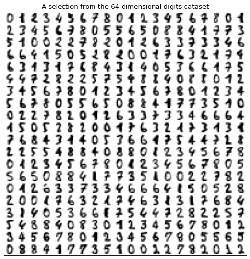

```python
n_img_per_row = 20
img = np.zeros((10 * n_img_per_row, 10 * n_img_per_row))
for i in range(n_img_per_row):
    ix = 10 * i + 1
    for j in range(n_img_per_row):
        iy = 10 * j + 1
        img[ix : ix + 8, iy : iy + 8] = X[i * n_img_per_row + j].reshape((8, 8))

plt.figure(num=None, figsize=(12, 8), dpi=80, facecolor="w", edgecolor="k")
plt.imshow(img, cmap=plt.cm.binary)
plt.xticks([])
plt.yticks([])
plt.title("A selection from the 64-dimensional digits dataset")
```

### Random Projection

We begin be the simplest embedding possible. We just randomly project the high-dimensional data onto the 2-dimensional plane. The embedding is already quite good. Why do random projections work already so well? This is due to the [Johnson-Lindenstrauss-Lemma](https://en.wikipedia.org/wiki/Johnson%E2%80%93Lindenstrauss_lemma) that we will cover in class.

```python
print("Computing random projection")
rp = random_projection.GaussianRandomProjection(n_components=2, random_state=42)
X_projected = rp.fit_transform(X)
```

```
Computing random projection
```

Scale and visualize the embedding vectors

```python
def plot_embedding(X, title=None):
    x_min, x_max = np.min(X, 0), np.max(X, 0)
    X = (X - x_min) / (x_max - x_min)

    plt.figure(num=None, figsize=(12, 8), dpi=80, facecolor="w", edgecolor="k")
    ax = plt.subplot(111)
    for i in range(X.shape[0]):
        plt.text(
            X[i, 0],
            X[i, 1],
            str(y[i]),
            color=plt.cm.Dark2(y[i]),
            fontdict={"weight": "bold", "size": 9},
        )

    if hasattr(offsetbox, "AnnotationBbox"):
        # only print thumbnails with matplotlib > 1.0
        shown_images = np.array([[1.0, 1.0]])  # just something big
        for i in range(X.shape[0]):
            dist = np.sum((X[i] - shown_images) ** 2, 1)
            if np.min(dist) < 4e-3:
                # don't show points that are too close
                continue
            shown_images = np.r_[shown_images, [X[i]]]
            imagebox = offsetbox.AnnotationBbox(
                offsetbox.OffsetImage(digits.images[i], cmap=plt.cm.gray_r), X[i]
            )
            ax.add_artist(imagebox)
    plt.xticks([]), plt.yticks([])
    if title is not None:
        plt.title(title)
```

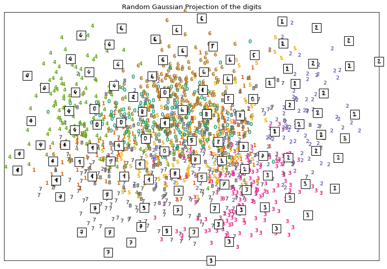

```python
plot_embedding(X_projected, "Random Gaussian Projection of the digits")
```

### Sparse Random Projection

```
Computing sparse random projection
```

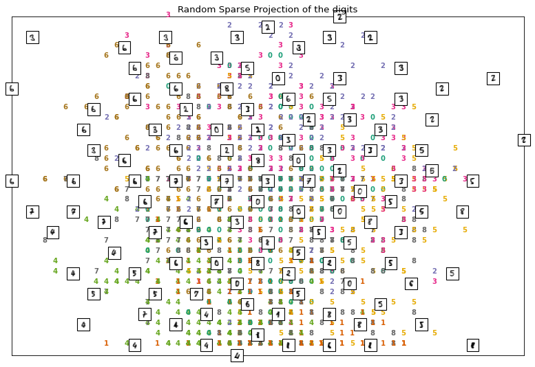

```python
print("Computing sparse random projection")
rp = random_projection.SparseRandomProjection(n_components=2, random_state=42)
X_projected = rp.fit_transform(X)
plot_embedding(X_projected, "Random Sparse Projection of the digits")
```

### Truncated SVD

For the Truncated Singular Value Decomposition we consider the vector corresponding to the 2 largest singular values of the SVD of the data $X$. Note that this is similar to PCA, without centering the data.

```
Computing SVD projection
Ratio of zero entries: 0.03125
```

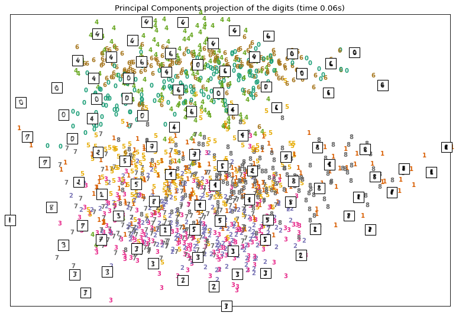

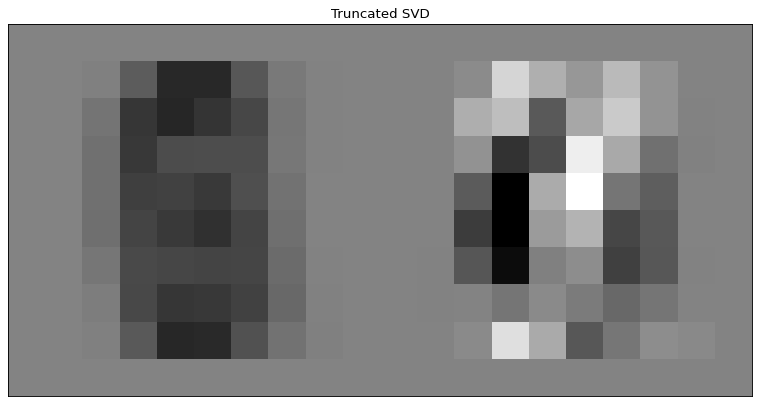

```python
print("Computing SVD projection")
t0 = time()
transformer = decomposition.TruncatedSVD(n_components=2)
X_pca = transformer.fit_transform(X)
plot_embedding(
    X_pca, "Principal Components projection of the digits (time %.2fs)" % (time() - t0)
)

print(f"Ratio of zero entries: { np.mean(transformer.components_ == 0)}")

img = np.zeros((10 * 1, 10 * 2))
for i in range(1):
    ix = 10 * i + 1
    for j in range(2):
        iy = 10 * j + 1
        img[ix : ix + 8, iy : iy + 8] = transformer.components_[j].reshape((8, 8))

plt.figure(num=None, figsize=(12, 8), dpi=80, facecolor="w", edgecolor="k")
plt.imshow(img, cmap=plt.cm.binary)
plt.xticks([])
plt.yticks([])
plt.title("Truncated SVD")
```

### Principal Component Analysis (PCA)

```
Computing PCA projection
Ratio of zero entries: 0.03125
```

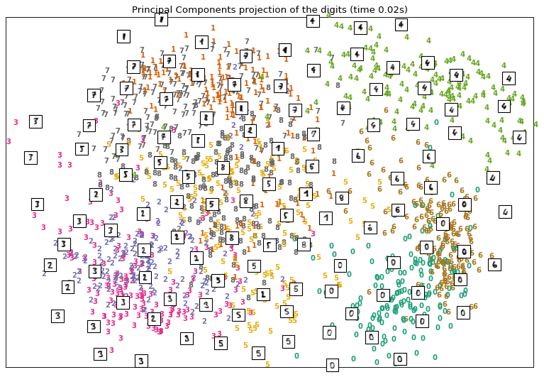

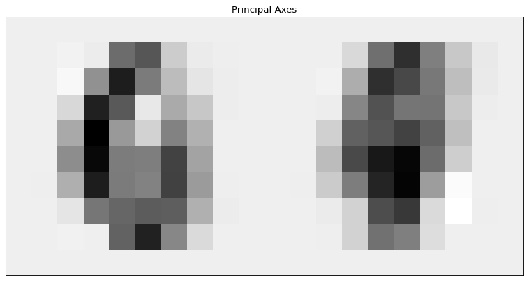

```python
print("Computing PCA projection")
t0 = time()
transformer = decomposition.PCA(n_components=2)
X_pca = transformer.fit_transform(X)
plot_embedding(
    X_pca, "Principal Components projection of the digits (time %.2fs)" % (time() - t0)
)

print(f"Ratio of zero entries: { np.mean(transformer.components_ == 0)}")
img = np.zeros((10 * 1, 10 * 2))
for i in range(1):
    ix = 10 * i + 1
    for j in range(2):
        iy = 10 * j + 1
        img[ix : ix + 8, iy : iy + 8] = (
            transformer.components_[j] * np.sqrt(transformer.singular_values_[j])
            + transformer.mean_
        ).reshape((8, 8))

plt.figure(num=None, figsize=(12, 8), dpi=80, facecolor="w", edgecolor="k")
plt.imshow(img, cmap=plt.cm.binary)
plt.xticks([])
plt.yticks([])
plt.title("Principal Axes")
```

### Sparse PCA

Standard PCA does not take sparsity into account. The above 3% zero entries are probably just down to the fact that the picture input has the property that most pixel in the edges are white. To compress the data we use Sparse PCA.

```
Ratio of zero entries: 0.203125
```

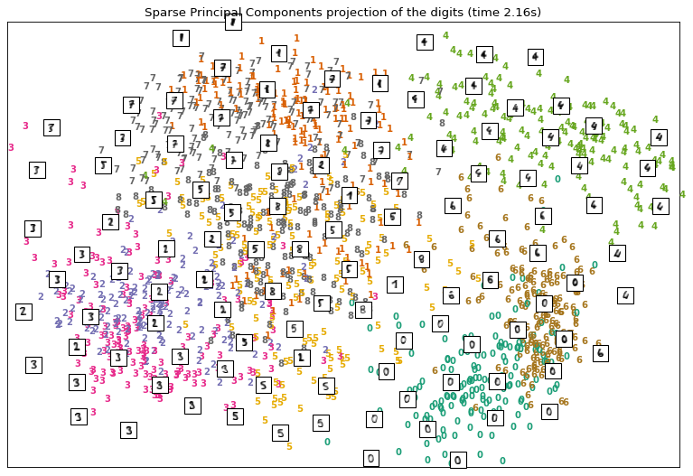

```python
t0 = time()
sparse_transformer = SparsePCA(n_components=2, random_state=0)
X_sparse_PCA = sparse_transformer.fit_transform(X)
plot_embedding(
    X_sparse_PCA,
    "Sparse Principal Components projection of the digits (time %.2fs)" % (time() - t0),
)
print(f"Ratio of zero entries: { np.mean(sparse_transformer.components_ == 0)}")
```

### Sparser PCA

The default option for `SparsePCA` sets the *sparsity* weight $\alpha$ to 1. We can increase $\alpha$ to get even sparser solutions, although there is a tradeoff with the embedding quality in the plane.

```
Ratio of zero entries: 0.7578125
```

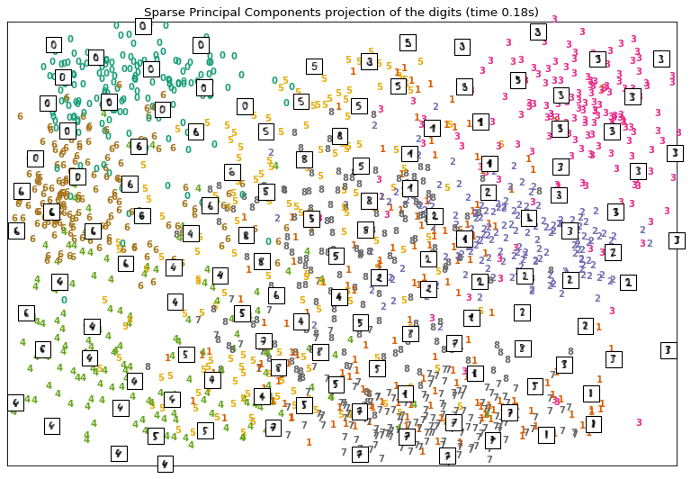

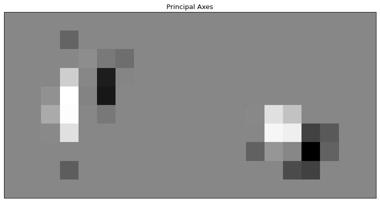

```python
t0 = time()
sparser_transformer = SparsePCA(n_components=2, alpha=50, random_state=0)
X_sparse_PCA = sparser_transformer.fit_transform(X)
plot_embedding(
    X_sparse_PCA,
    "Sparse Principal Components projection of the digits (time %.2fs)" % (time() - t0),
)
print(f"Ratio of zero entries: { np.mean(sparser_transformer.components_ == 0)}")

img = np.zeros((10 * 1, 10 * 2))
for i in range(1):
    ix = 10 * i + 1
    for j in range(2):
        iy = 10 * j + 1
        img[ix : ix + 8, iy : iy + 8] = (sparser_transformer.components_[j]).reshape(
            (8, 8)
        )

plt.figure(num=None, figsize=(12, 8), dpi=80, facecolor="w", edgecolor="k")
plt.imshow(img, cmap=plt.cm.binary)
plt.xticks([])
plt.yticks([])
plt.title("Principal Axes")
```

## Multi-dimensional Scaling (MDS)

[Multidimensional scaling](https://en.wikipedia.org/wiki/Multidimensional_scaling) ([`MDS`](https://scikit-learn.org/stable/modules/manifold.htmlgenerated/sklearn.manifold.MDS.html#sklearn.manifold.MDS)) seeks a low-dimensional representation of the data in which the distances respect well the distances in the original high-dimensional space.

In general, [`MDS`](https://scikit-learn.org/stable/modules/manifold.htmlgenerated/sklearn.manifold.MDS.html#sklearn.manifold.MDS) is a technique used for analyzing similarity or dissimilarity data. It attempts to model similarity or dissimilarity data as distances in a geometric spaces. The data can be ratings of similarity between objects, interaction frequencies of molecules, or trade indices between countries.

There exists two types of MDS algorithm: metric and non metric. In the scikit-learn, the class [`MDS`](https://scikit-learn.org/stable/modules/manifold.htmlgenerated/sklearn.manifold.MDS.html#sklearn.manifold.MDS) implements both. In Metric MDS, the input similarity matrix arises from a metric (and thus respects the triangular inequality), the distances between output two points are then set to be as close as possible to the similarity or dissimilarity data. In the non-metric version, the algorithms will try to preserve the order of the distances, and hence seek for a monotonic relationship between the distances in the embedded space and the similarities/dissimilarities.

```
Computing MDS embedding
```

```
Done. Stress: 358452640.238472
```

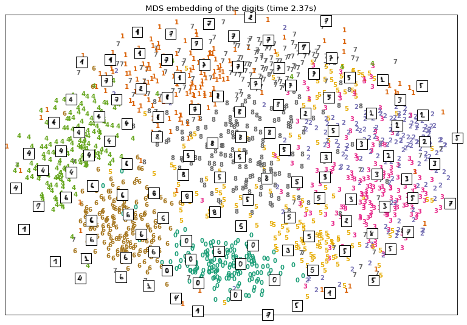

```python
print("Computing MDS embedding")
clf = manifold.MDS(n_components=2, n_init=1, max_iter=100)
t0 = time()
X_mds = clf.fit_transform(X)
print("Done. Stress: %f" % clf.stress_)
plot_embedding(X_mds, "MDS embedding of the digits (time %.2fs)" % (time() - t0))
```

## Non-negative Matrix Factorization (NMF)

NMF aims to decompose data $X$ into a product of low rank matrices $X \approx WH$ such that $\|X - WH\|$ is small for some norm (default is usually Frobenius norm).

```
Computing NMF embedding
```

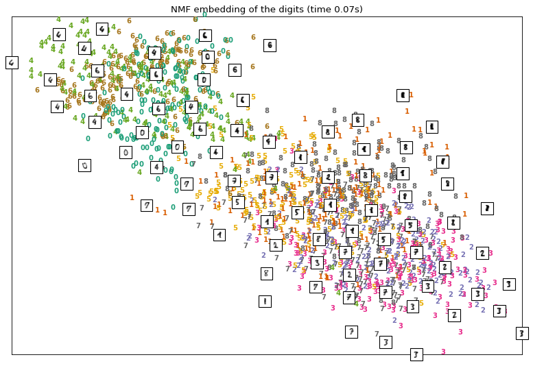

```python
print("Computing NMF embedding")
NMF_transformer = decomposition.NMF(
    n_components=2, alpha_W=1, alpha_H=1, max_iter=10000, init="random"
)
t0 = time()
X_nmf = NMF_transformer.fit_transform(X)
plot_embedding(X_nmf, "NMF embedding of the digits (time %.2fs)" % (time() - t0))
```